Lake Name: Beaver Dam Lake

Lake acreage: 167.2

County: ORANGE

PWLID: 1303-0021

Waterbody Classification: B

Coordinates: 41.442001,-74.115898

Is this waterbody a public water supply: No

Are there DOH desingated beaches on this waterbody: Yes

Open Water Indicators

2018 Sampling Results

Seasonal Change

06-04

06-18

07-01

07-15

07-29

08-12

08-27

09-09

Clarity (m)

2.00

0.65

1.90

1.00

1.20

1.25

1.15

1.15

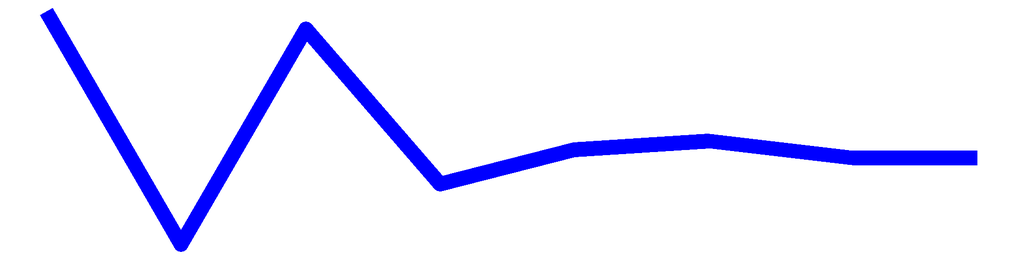

Surface TP (mg/L)

0.03

0.05

0.03

0.02

0.05

0.04

0.04

0.04

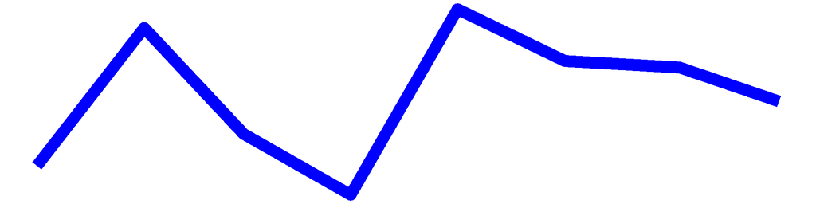

Surface TDP (mg/L)

0.01

0.01

0.01

0.03

0.01

0.02

0.02

0.02

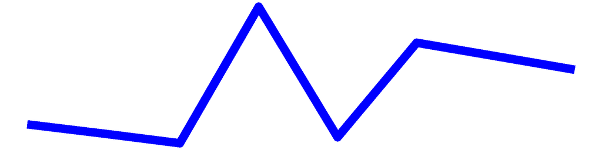

Deep TP (mg/L)

0.55

0.76

1.23

1.64

1.93

2.22

2.54

2.37

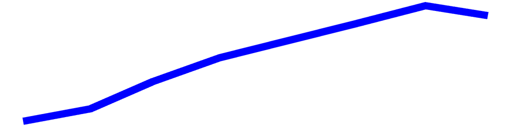

Deep TDP (mg/L)

0.36

0.50

0.44

0.83

0.49

0.84

0.78

0.63

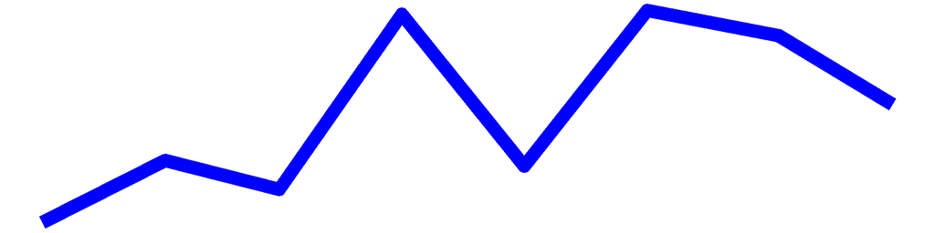

TN (mg/L)

0.74

1.06

0.86

1.06

1.14

1.06

0.91

0.68

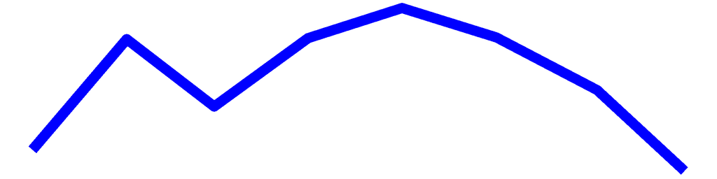

TDN (mg/L)

0.72

0.89

0.79

0.94

1.05

0.92

0.86

0.60

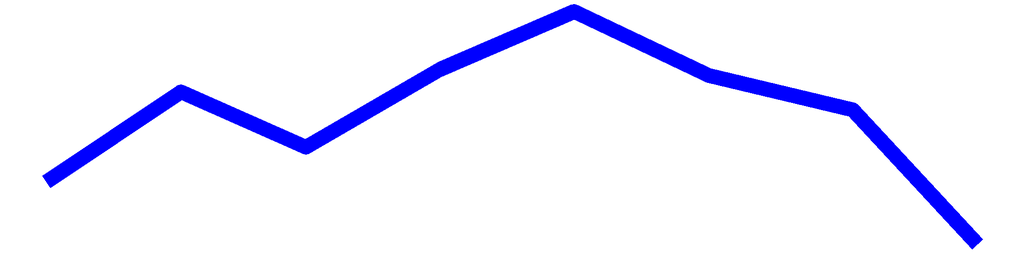

TN:TP

26.62

21.09

26.26

45.84

21.56

23.75

20.84

17.78

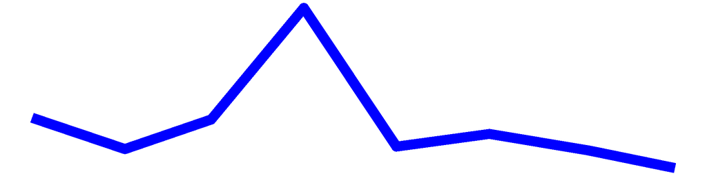

Surface NH3 (mg/L)

0.06

0.05

0.02

0.08

0.06

0.02

0.03

0.06

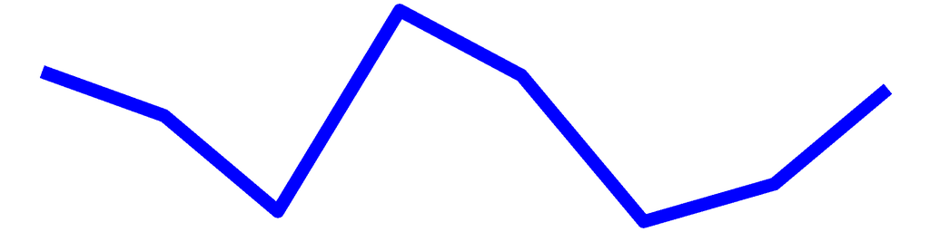

Deep NH3 (mg/L)

1.55

2.37

3.42

4.63

5.84

7.79

9.24

10.40

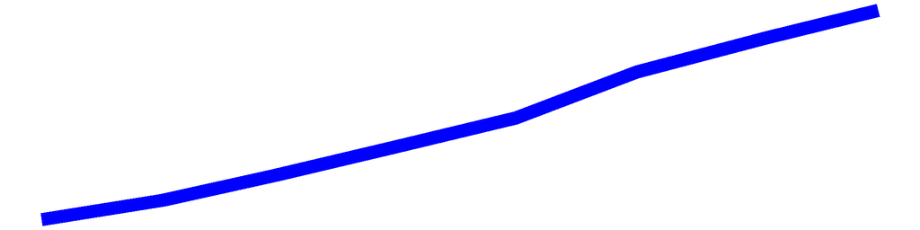

Chl.a (ug/L)

25.80

51.20

15.70

29.20

43.30

35.70

25.80

27.30

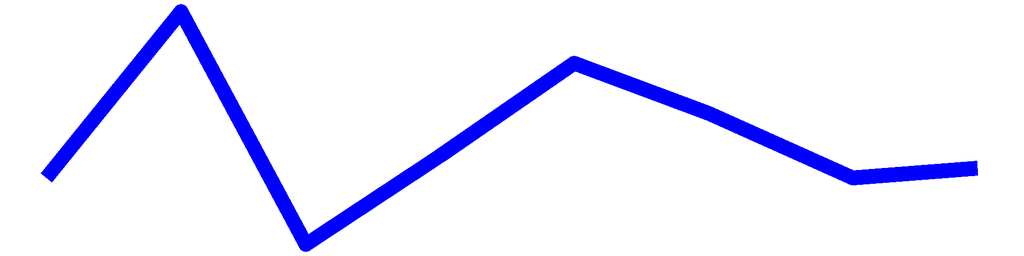

pH

7.75

7.38

8.32

8.42

8.61

7.77

7.21

6.75

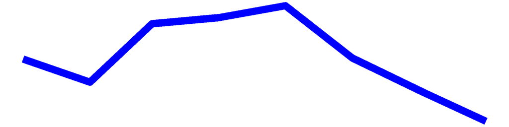

Cond (umho/cm)

463.10

386.10

439.40

387.10

497.20

488.00

454.00

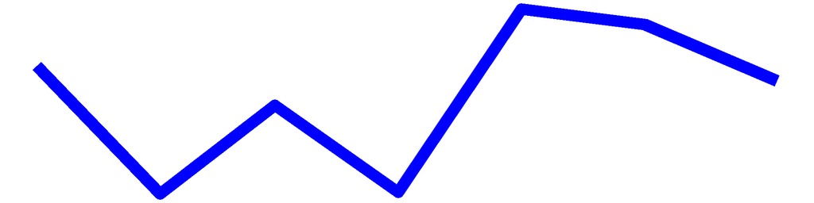

Surface Calcium (mg/L)

Bottom Calcium (mg/L)

Surface Chloride (mg/L)

91.90

16.60

Bottom Chloride (mg/L)

Upper Temp (degC)

22.00

22.00

27.10

27.50

28.30

27.30

25.10

22.50

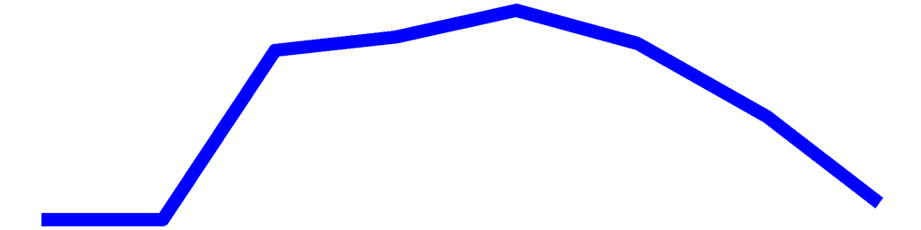

Deep Temp (degC)

12.00

12.00

14.40

15.00

15.00

15.20

15.20

14.60

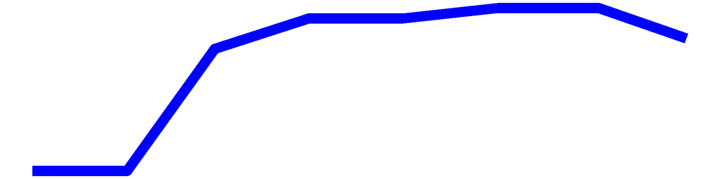

FP BG Chl.a (ug/L)

31.16

62.56

19.41

49.21

50.23

58.06

35.34

33.61

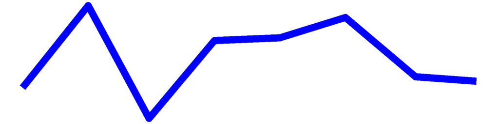

## Beaver Dam Lake – Sampling Season Results

### HABs Status

#### Open Water Algae

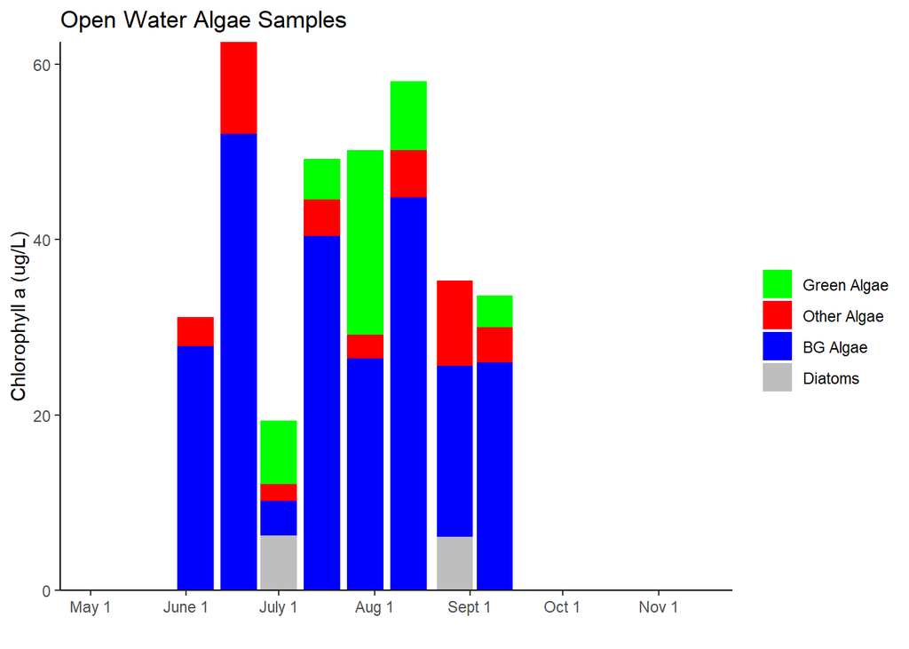

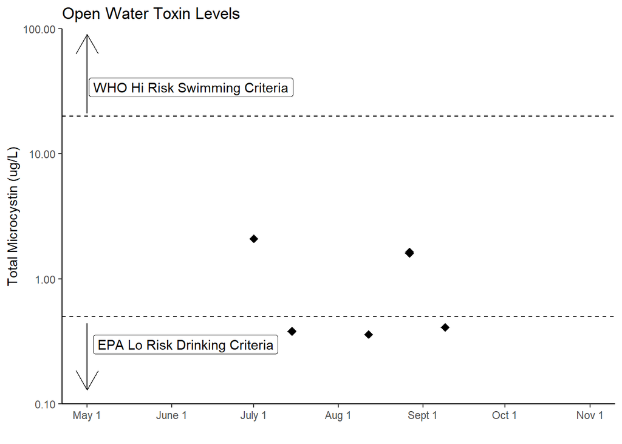

#### Shoreline Algae

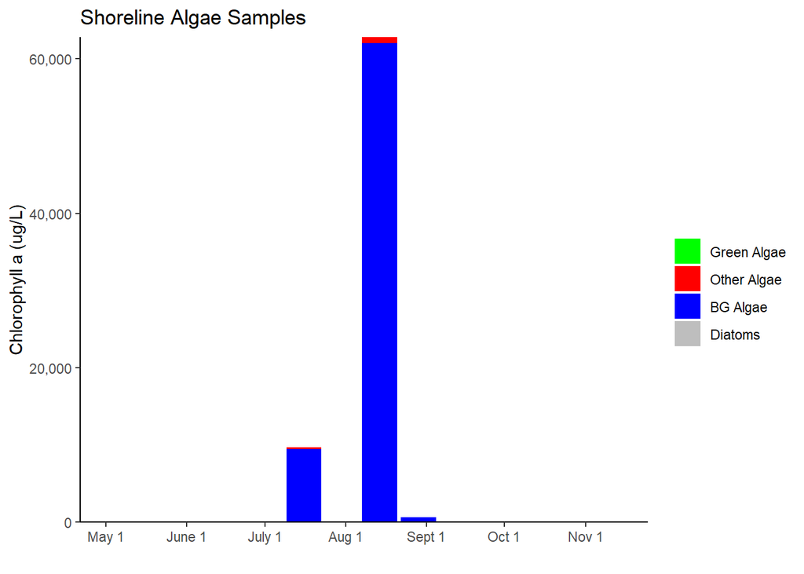

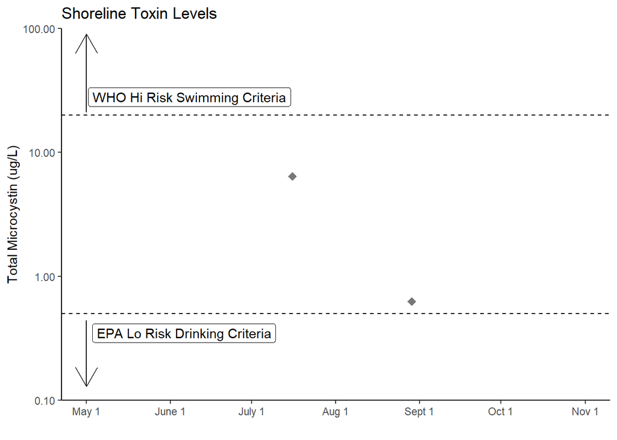

## Beaver Dam Lake Long-Term Trend Analysis

#### Clarity

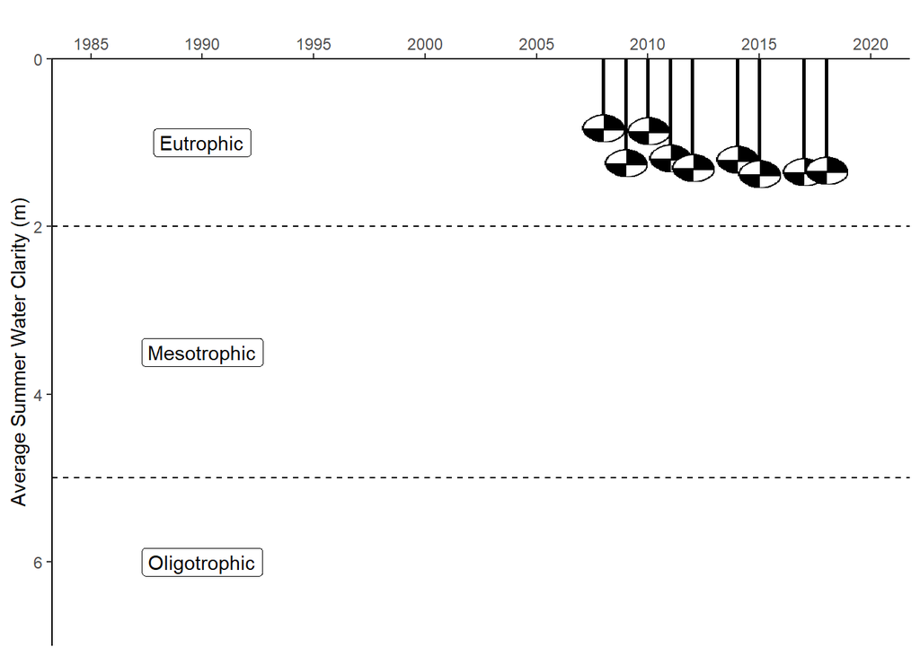

#### Chlorophyll *a*

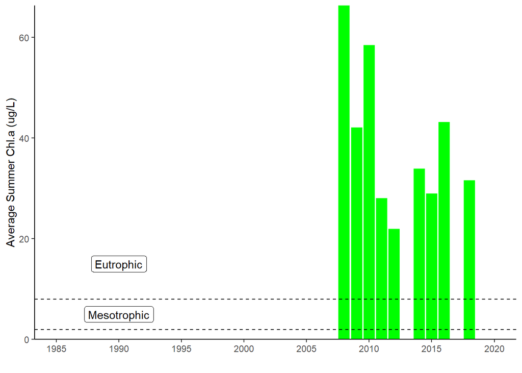

#### Surface and Deep Phosphorus

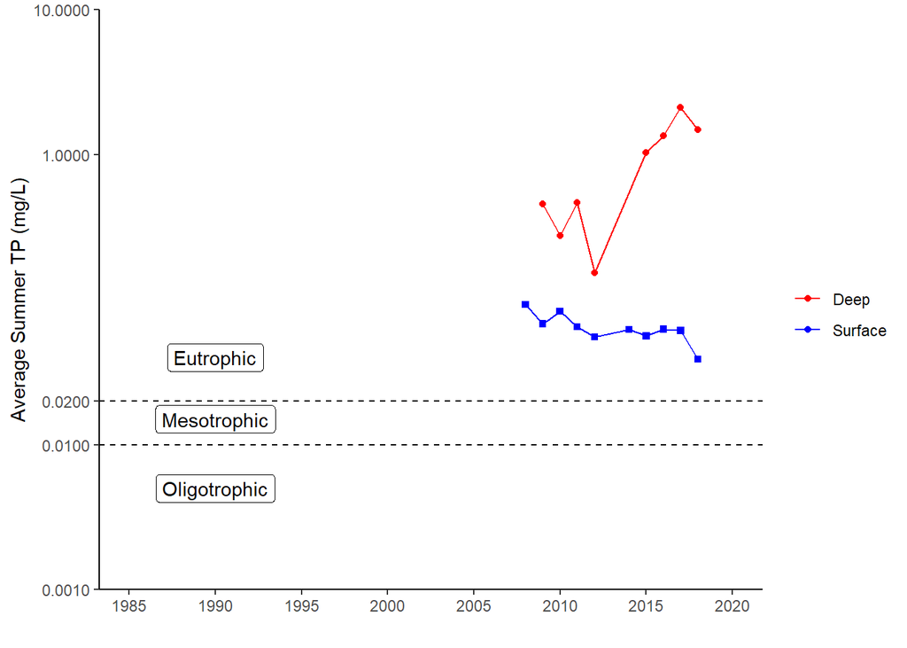

#### Nitrogen

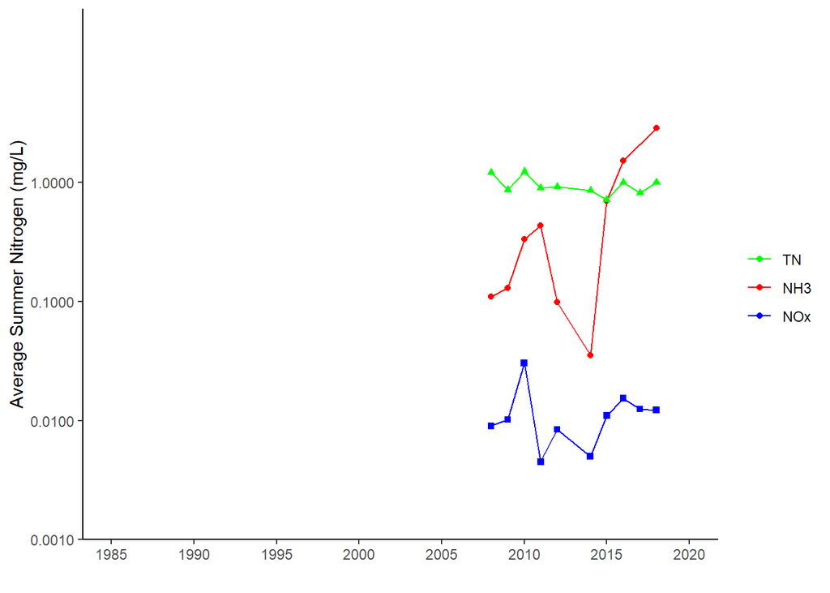

#### TN : TP

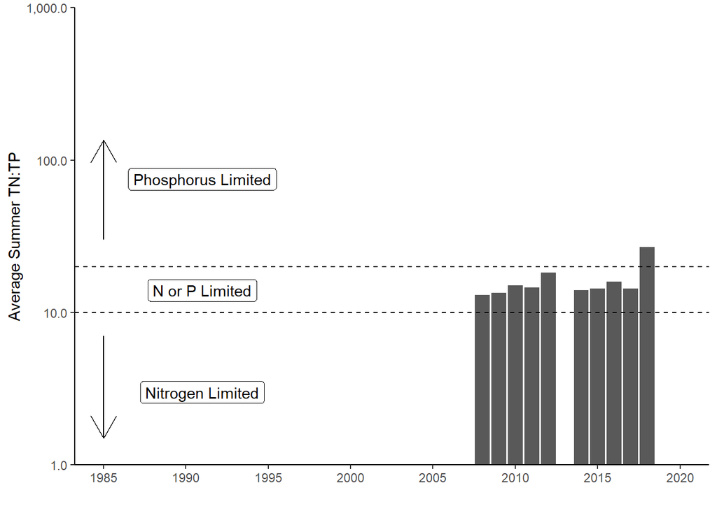

#### pH

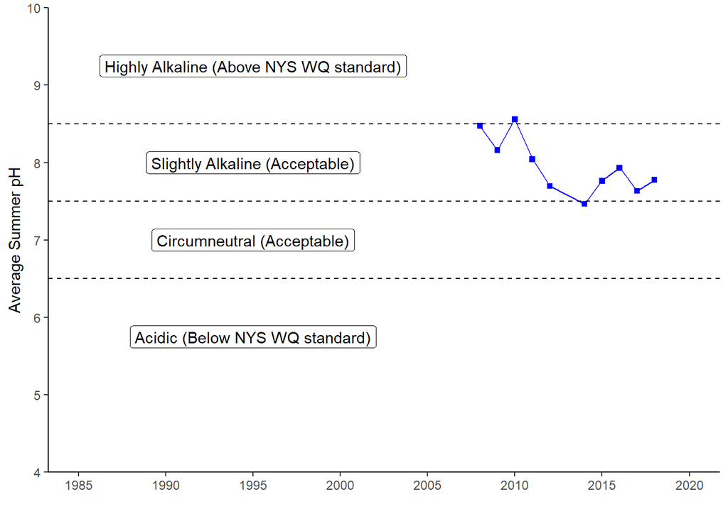

#### Specific Conductance

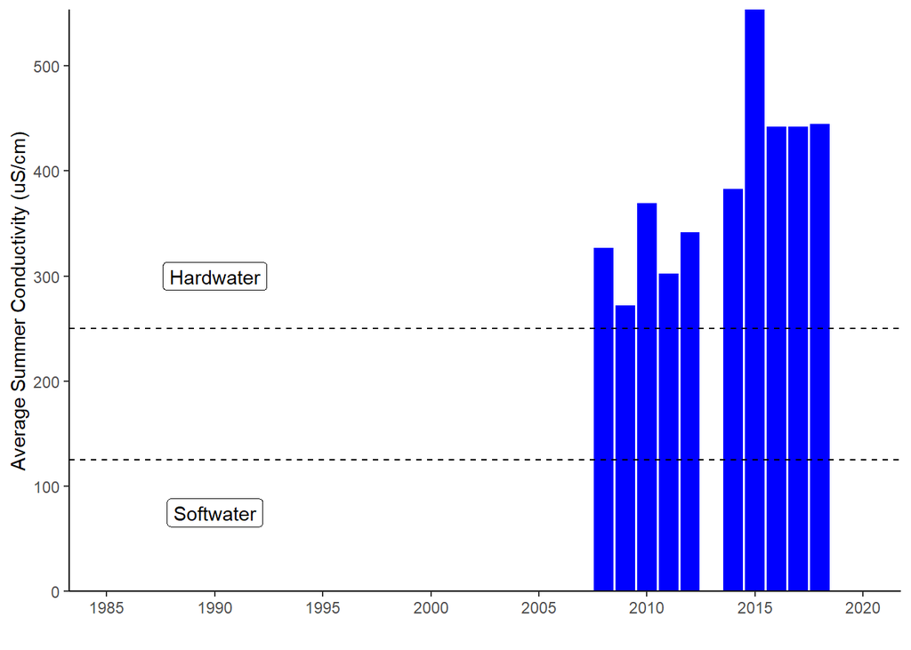

#### Calcium

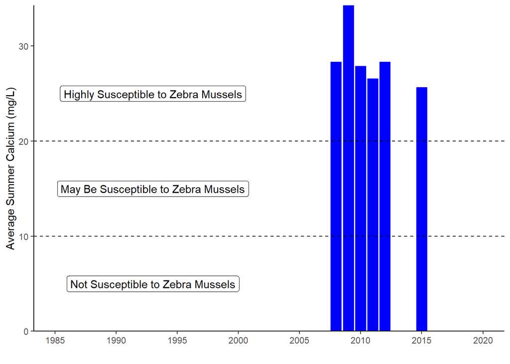

#### Chloride

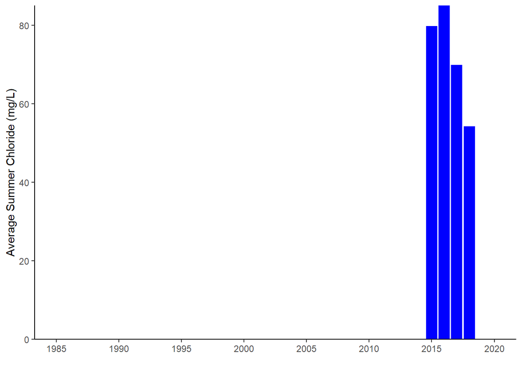

#### Color

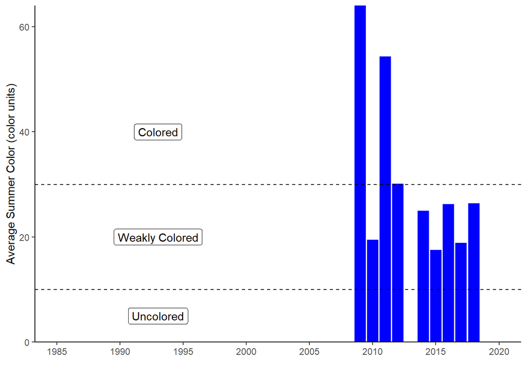